# **[Universidade Federal Rural de Pernambuco](http://ufrpe.br/)** **[Departamento de Matemática](http://www.dm.ufrpe.br/)** **[Disciplina: Cálculo M I](https://sites.google.com/site/ricardonunesmachadojr/disciplinas/c%C3%A1lculo-mi)** **[Prof. Ricardo Machado](https://sites.google.com/site/ricardonunesmachadojr/)**

## [Índice de Aulas](https://sagectu.com.br/calculo1.github.io/index.html) Aula 8

## Preparação para o Teorema do Valor Médio (TVM) Teorema do Valor Médio (TVM) Aplicações do TVM

# Referências:

[figure not shown]

[figure not shown]

### Observação: Nota de aula produzida usando o software [SageMath](http://www.sagemath.org/), usando o notbook [Jupyter](https://jupyter.org/). Use o SageMathCell com vários exemplos em: sagectu.com.br/sagecell.html

## 1 - Preparação para o Teorema do Valor Médio (TVM)

## Teorema 1.1: (Teorema de Weierstrass) Seja $f$ uma função contínua em $[a, b]$, então existem $x_1$ e $x_2$ em $[a, b]$ tais que $$f(x_1)\leq f(x)\leq f(x_2) ~~~ \forall ~~ x\in [a, b].$$

```python
df = diff(x^3-10*x^2+50)
solve(df==0, x)
```

```
[x == (20/3), x == 0]
```

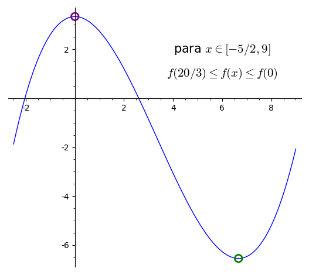

```python
weierstrass()
```

## Demonstração: Veja págino 81 do livro: Análise Real Vol 1. Elon Lages Lima. $\blacksquare$

## Teorema 1.2: (Teorema de Rolle) Seja $f$ uma função contínua em $[a, b]$, derivável em $(a, b)$ com $f(a)=f(b)$, então existirá pelo menos um $c\in (a, b)$ tal que $f'(c)=0$.

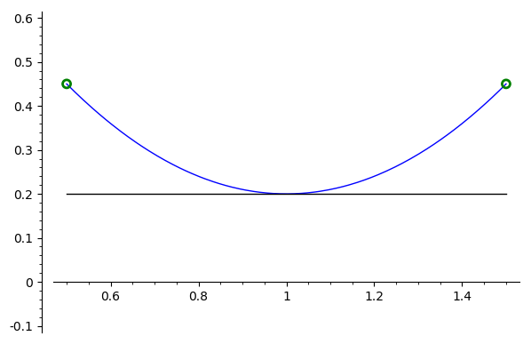

```python
rolle(x^2-2*x+1.2, 1, (0.5, 1.5), (-0.1, 0.6))
```

## Demonstração: Caso 1: $f$ é constante em $[a, b]$. Neste caso $f'(x)=0$ em $(a, b)$, logo, para qualquer $c\in (a, b)$, temos $f'(c)=0$. Caso 2: $f$ não é constante em $[a, b]$. Como $f$ é contínua em $[a, b]$, pelo Teorema de Weierstrass, existem $x_1$ e $x_2$ em $[a, b]$, tais que $f(x_1)$ e $f(x_2)$ são, respectivamente, os valores mínimo e máximo de $f$ em $[a, b]$. Como $f$ não é constante, temos $f(x_1)\neq f(x_2)$ e como $f(a) = f(b)$, necessariamente $x_1$ ou $x_2$ pertence a $(a, b)$. Daí, como a derivada nos pontos de mínimo e máximo são iguais a zero, temos $f'(x_1)=0$ ou $f'(x_2)=0$. Portanto, existe $c$ em $(a, b)$ tal que $f'(c)=0$. $\blacksquare$

## 2 - Teorema do Valor Médio (TVM)

## Teorema 2.1: (Teorema do Valor Médio (TVM)) Se $f$ for contínua em $[a, b]$ e derivável em $(a, b)$, então existirá pelo menos um $c$ em $(a, b)$ tal que $$ f'(c) = \frac{f(b)-f(a)}{b-a} $$

## Demonstração: Considere a função $g(x)$, com $x\in[a, b]$, dada por $$ g(x) = f(x) -\left(f(a) + \frac{f(b)-f(a)}{b-a}(x-a)\right) $$ Observe que $g(a)=g(b)$ e que $$ g'(x) = f'(x) - \frac{f(b)-f(a)}{b-a}. $$ Pelo Teorema de Rolle, existe $c\in(a, b)$ tal que $$g'(c)=0$$ Ou seja, $$ 0 = f'(c) - \frac{f(b)-f(a)}{b-a} \Rightarrow f'(c) = \frac{f(b)-f(a)}{b-a}. $$ $\blacksquare$

## Exemplo 1: Gráfico da função $f(x)=x^3-x^2$ no intervalo $(-0.7, 1.4)$ com dois valores $c$, tais que $$ f'(c) = \frac{f(1.4)-f(-0.7)}{1.4-(-0.7)} $$

```python
f = x^3-x^2
sol = solve( diff(f, x) == (f(1.4)-f(-0.7))/(1.4-(-0.7)),x )
show(sol)
n(sol[0].rhs()), n(sol[1].rhs())
```

$$\newcommand{\Bold}[1]{\mathbf{#1}}\left[x = -\frac{1}{30} \, \sqrt{331} + \frac{1}{3}, x = \frac{1}{30} \, \sqrt{331} + \frac{1}{3}\right]$$

```
(-0.273113513288675, 0.939780179955342)
```

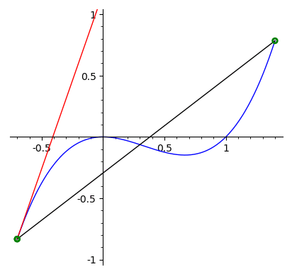

```python
anime_grafico_f_tan_tvm(x^3 - x^2, 0.025, (-0.7, 1.4), (-1, 1))
```

## 3 - Aplicações do TVM:

## Intervalos de Crescimento e de Decrescimento Como Consequência do TVM temos o seguinte teorema:

## Teorema 3.1 Seja $f$ contínua no intervalo $(a,b)$. a) Se $f'(x)>0$ para todo $x \in (a,b)$, então $f$ será estritamente crescente em $(a,b)$. b) Se $f'(x)<0$ para todo $x \in (a,b)$, então $f$ será estritamente decrescente em $(a,b)$.

## Demonstração: a) Já que $f'(x)>0$, $\forall x \in (a, b)$, sejam, $c, d \in (a, b)$, com $c<d$. Vamos mostrar que $f(c)<f(d).$ Como $f$ satisfaz as hipóteses do TVM, existe $\tilde{x}\in (c, d)$ tal que $$ f(d)-f(c) = f'(\tilde{x})(d-c). $$ Como $f'(\tilde{x})>0$, pois $\tilde{x}\in (a,b)$ e $d-c>0,$ segue $$ f(d) - f(c) > 0 \Rightarrow f(c)<f(d). $$ Portando, como a escolha de $c < d$, foi arbitrária, o resultado segue. $\blacksquare$

```python
df = diff(2*x^3-x^2+3*x+1, x)
df.show()
```

$$\newcommand{\Bold}[1]{\mathbf{#1}}6 \, x^{2} - 2 \, x + 3$$

```python
show(solve(df==0, x))
```

[output not shown]

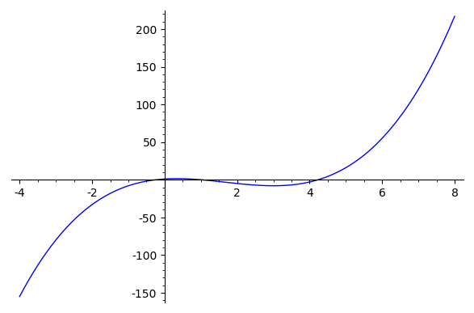

```python
plot(x^3-5*x^2+3*x+1, (-4, 8))
```

## Exercício 3.1 Determine os intervalos de crescimento e de decrescimento de $$f(x) = \dfrac{x^2-x}{1+3x^2}.$$ Esboce o gráfico. $\blacksquare$

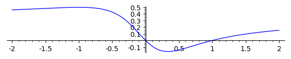

```python
plot((x^2-x)/(1+3*x^2), (-2, 2), aspect_ratio=1)
```

## Concavidade e Pontos de Inflexão

## Definição 3.1 (Concavidade) Sejam $f$ uma função derivável no intervalo $(a,b)$ e $T_p(x)$ a reta tangente em $(p, f(p))$ ao gráfico de $f$, $p\in (a, b)$. a) Dizemos que $f$ tem *concavidade para cima* em $(a, b)$ se $$ f(x)>T_p(x) $$ para quaisquer $x$ e $p$ em $(a, b)$, com $x\neq p.$ b) Dizemos que $f$ tem *concavidade para baixo* em $(a, b)$ se $$ f(x)<T_p(x) $$ para quaisquer $x$ e $p$ em $(a, b)$, com $x\neq p.$ $\blacksquare$

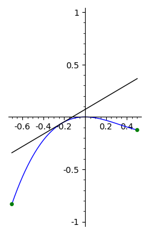

```python
rolle(x^3-x^2, 1, (-0.7, 0.5), (-1, 1))
```

## Definição 3.2 (Ponto de inflexão) Sejam $f$ uma função e $p\in D_f$, com $f$ contínua em $p$. Dizemos que $p$ é *ponto de inflexão* de $f$ se existem $a, b \in D_f$, com $p\in (a, b)$, tal que as concavidades de $f$ em $(a, p)$ e em $(p, b)$ sejam opostas. $\blacksquare$

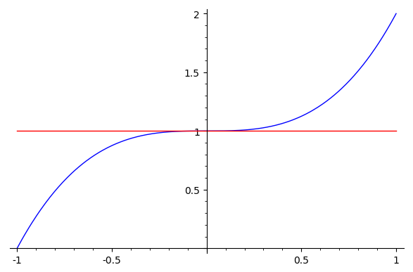

```python
p1 = plot(x^3+1)
p2 = plot(1, color='red')
(p1+p2)
```

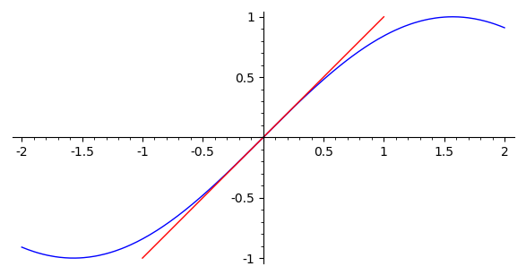

```python
p1 = plot(sin(x), (-2, 2), aspect_ratio=1)
p2 = plot(x, color='red')
(p1+p2)
```

## Teorema 3.2 Seja $f$ uma função que admite derivada até 2ª ordem no intervalo $(a, b)$. a) Se $f''(x)>0$ para $x \in (a,b)$, então $f$ terá *concavidade para cima* em $(a, b)$. b) Se $f''(x)<0$ para $x \in (a,b)$, então $f$ terá *concavidade para baixo* em $(a, b)$.

## Demonstração: a) Sejam $f''(x)>0$ para $x \in (a,b)$ e $p \in (a, b)$ arbitrário. Vamos mostrar que $$ f(x)>T_p(x), $$ para todo $x\in (a, b)$, com $x\neq p$, na qual, $T_p(x) = f'(p)(x-p)+f(p)$. Considere $g(x) = f(x)-T_p(x)$, logo $$g'(x) = f'(x)-f'(p), ~~ x\in(a,b), $$ pois $T_p'(x) = f'(p)$. Como $f''(x)>0$ em $(a, b)$, pelo Teorema 3.1, $f'$ é estritamente crescente em $(a, b)$. Então, $$ \begin{cases} g'(x)>0, & \text{para } x>p \\ g'(x)<0, & \text{para } x<p. \end{cases}$$ Mais uma vez pelo Teorema 3.1, $$ \begin{cases} g(x) \text{ é estritamente decrescente para } x<p, \text{ com } x\in (a, b)\\ g(x) \text{ é estritamente crescente para } x>p, \text{ com } x\in (a, b). \end{cases}$$ Como $g(p)=0$, temos $g(x)>0$ para todo $x\in(a, b)$, $x\neq p$. E como $g(x) = f(x) - T_p(x)$, temos $$f(x)>T_p(x) \text{ para todo } x\in(a, b), x\neq p. $$ $\blacksquare$

## Exemplo 3.2 Estude a função $$f(x) = x^3-3x^2-9x $$ com relação à concavidade e pontos de inflexão. $\blacksquare$

## Solução $$f''(x) = 6x-6$$$$6x-6 = 0 \Leftrightarrow x = 1 $$$$ \begin{cases} 6x-6>0, & \text{para } x>1\text{. Concavidade para cima em } (1, +\infty) \\ 6x-6<0, & \text{para } x<1\text{. Concavidade para baixo em } (-\infty, 1) \\ 6x-6=0, & \text{Ponto de inflexão em } x=1. \end{cases}$$ $\blacksquare$

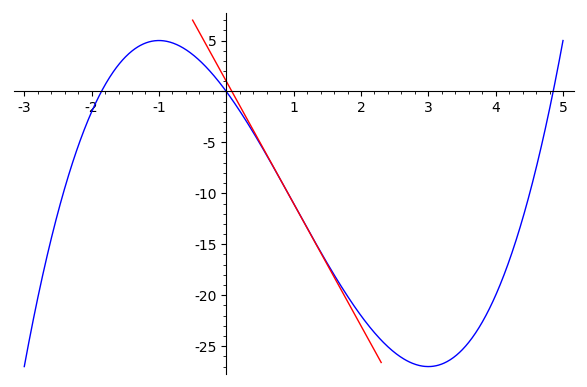

```python
f = x^3-3*x^2-9*x
p1 = plot(f, (-3, 5))
p2 = plot( diff(f, x)(x=1)*(x-1) + f(1), (-0.5, 2.3), color='red')
(p1+p2)
```

## Exercício 3.2 Estude a função $$f(x) = x^2+\frac{1}{x} $$ com relação à concavidade e pontos de inflexão. $\blacksquare$

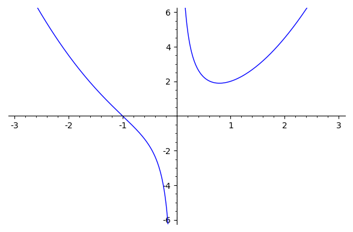

```python
plot(x^2+1/x, (-3, 3), ymin=-6, ymax=6, detect_poles='show')
```